# Презентация по лабораторной работе 3

Соловьев Богдан Михайлович

kulyabov-ds@rudn.ru

Российский университет дружбы народов

## Цель работы

Исследовать методы агентного моделирования на примере модели DaisyWorld

## Задание

Создать рабочий каталог для кода.

Установить необходимые пакеты.

Выполнить предложенный код.

Преобразовать код в литературный стиль.

Сгенерировать из литературного кода:

чистый код;

jupyter notebook;

документацию в формате Quarto.

Выполнить код из jupyter notebook.

Интегрировать документацию в формате Quarto в отчёт.

Добавить в код в литературном стиле вычисление для набора параметров.

Сгенерировать из литературного кода с параметрами:

чистый код;

jupyter notebook;

документацию в формате Quarto.

Выполнить код из jupyter notebook с параметрами.

Интегрировать документацию с параметрами в формате Quarto в отчёт.

Результирующие файлы не удаляйте, выложите на git.

## Теоретическое введение

В модели Daisyworld агентами являются чёрные и белые маргаритки. Они живут на клеточной сетке (среда).

Свойства агентов: вид и возраст.

Правила:

Маргаритки изменяют локальную температуру за счёт разного альбедо.

Температура влияет на вероятность размножения (чем ближе к оптимуму, тем выше шанс заселить соседнюю пустую клетку).

Агенты стареют и умирают после определённого возраста.

Среда (температура) диффундирует между клетками.

3.2.2.1 Агенты

Маргаритки двух типов — чёрные (black) и белые (white). Каждая маргаритка занимает одну клетку сетки и имеет возраст (количество шагов с момента появления).

3.2.2.2 Пространство

Двумерная квадратная сетка (например, 30×30) с периодическими границами.

3.2.2.3 Параметры

luminosity – солнечная постоянная (может изменяться со временем).

albedo_black, albedo_white – альбедо чёрных и белых маргариток.

surface_albedo — альбедо пустой почвы.

max_age — максимальный возраст маргаритки.

3.2.2.4 Динамика

Для каждой клетки рассчитывается локальная температура.

Каждая маргаритка может погибнуть с вероятностью, зависящей от температуры. Если температура выходит за допустимый диапазон, вероятность смерти повышается.

Если клетка пуста, на неё может попасть семя от соседней маргаритки. Вероятность успешного прорастания зависит от температуры клетки.

Если вероятность превышает случайное число, на пустой клетке появляется новая маргаритка того же цвета, что и родительская.

# Выполнение лабораторной работы

## Модель DaisyWorld

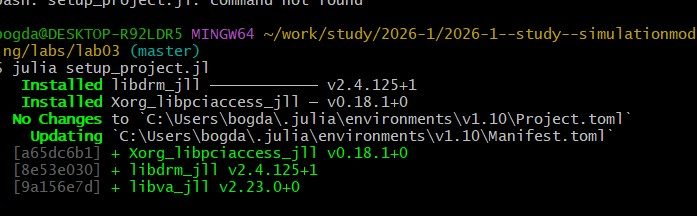

Рисунок 1: setup_project

Создаю файл, в котором перечисляю все необходимые библиотеки для работы над лабораторной (рис. 2).

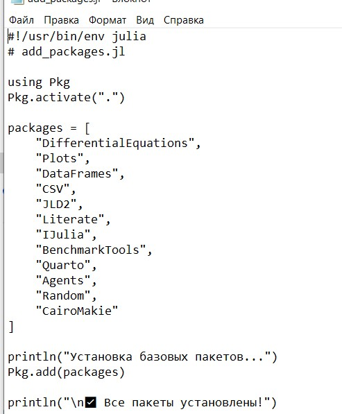

Рисунок 2: ПАКАЕТЫ

Запускаю этот файл (рис. 3):

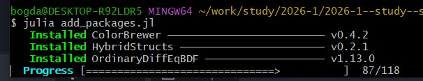

Рисунок 3: выполнение

Создаём вспомогательный скрипт, где определяется тип агента и функция шага (рис. 4)

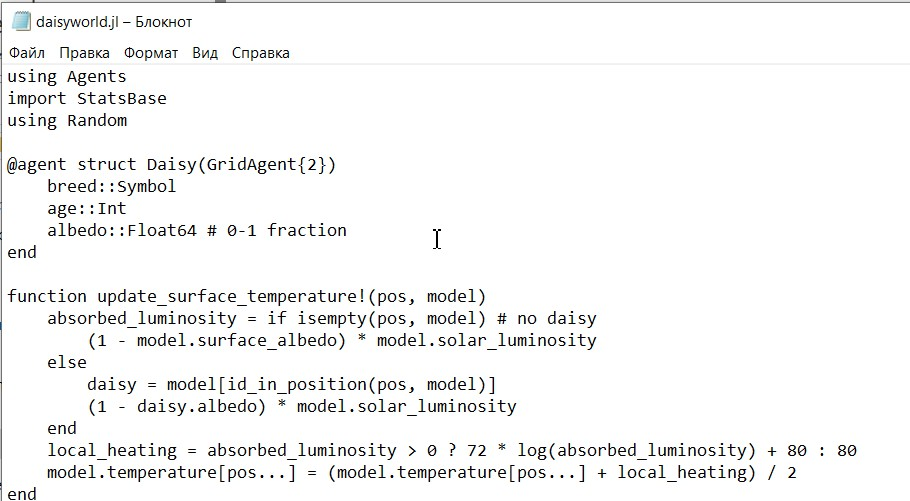

Рисунок 4: так выглядит файл(не полностью)

Выполняем (рис. 5)

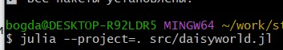

Рисунок 5: Выполнение

Пишем новый скрипт, который создаёт heatmap модели, на которой будут также запечатлены цветы (рис. 6)

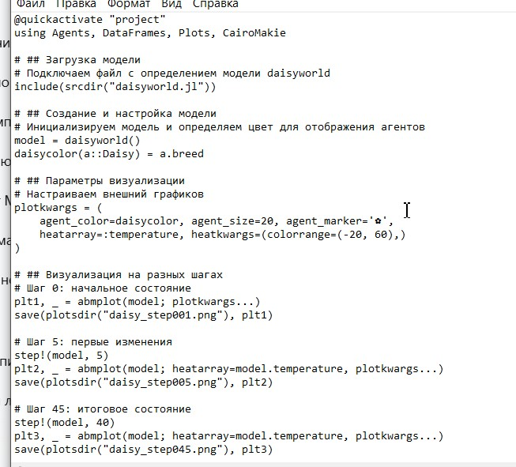

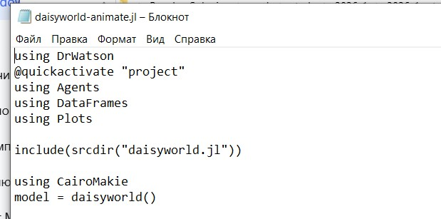

Рисунок 7: скрпит видео

[figure not shown]

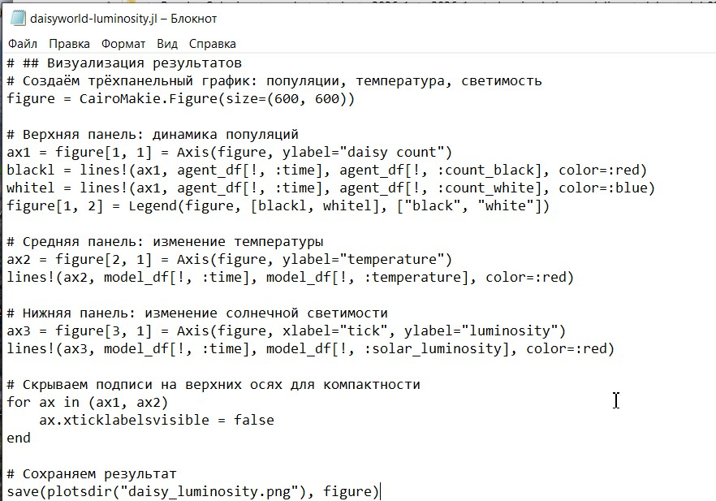

Рисунок 9: код

Расширим базовую визуализацию за счёт параметров (рис. 10)

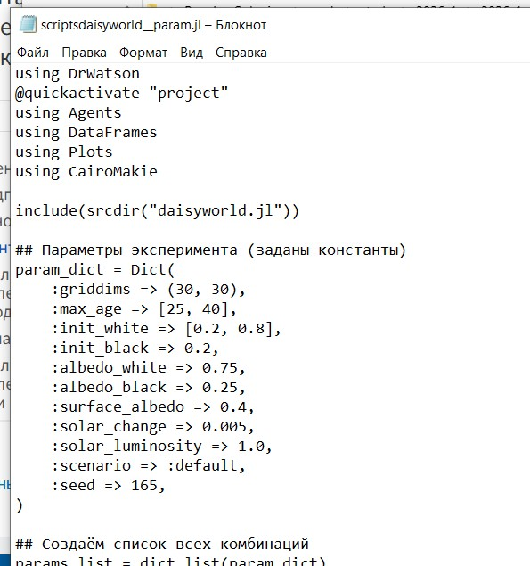

Рисунок 10: код

Построим график изменения числа маргариток в зависимости от модельного времени с разными параметрами модели. (рис. 11)

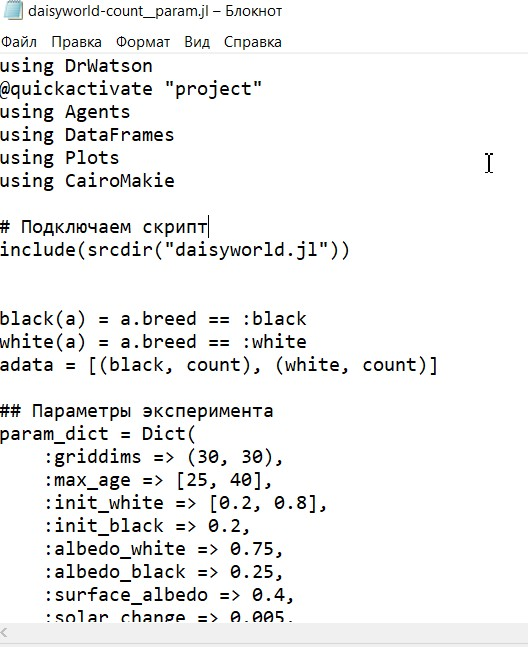

Рисунок 11: код

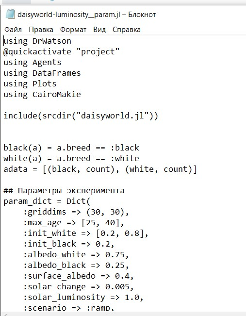

Рисунок 12: код

[figure not shown]

Рисунок 13

# Выводы

Я познакомился с агентной моделью DaisyWorld, научился моделироваить сложную систему, которая меняется под действием сущностей (агентов)

# Список литературы